# Assessment1

Aanchal s4651687

28/08/2021

# **RMarkdown editing**

**RMarkdown** is a framework that provides a literate programming format for data science. RMarkdown is a *file format for making dynamic documents with R*. An R Markdown document is written in markdown and contains chunks of embedded R code.

For more details on using R Markdown see http://rmarkdown.rstudio.com.

#### Q-5

```r
library(tidyverse)
library(knitr)

data<-
read_csv('https://rmarkdown.rstudio.com/lesson-8.html')
```

#### Q-6 Insert an R chunk and create a variable with this dataset

```r
fastfood <-
read_csv("https://raw.githubusercontent.com/rfordatascience/tidytuesday/master/data/2018/2018-09-04/fastfood_calories.csv")
```

```
## * `` -> ...1
```

#### Q-7 Display the first 10 rows of the dataset

```r
fastfood%>%head(10)
```

```
## # A tibble: 10 x 18
##     ...1 restaurant item            calories cal_fat total_fat sat_fat trans_fat
##    <dbl> <chr>      <chr>              <dbl>   <dbl>     <dbl>   <dbl>     <dbl>
##  1     1 Mcdonalds  Artisan Grille~      380      60         7       2       0
##  2     2 Mcdonalds  Single Bacon S~      840     410        45      17       1.5
##  3     3 Mcdonalds  Double Bacon S~     1130     600        67      27       3
##  4     4 Mcdonalds  Grilled Bacon ~      750     280        31      10       0.5
##  5     5 Mcdonalds  Crispy Bacon S~      920     410        45      12       0.5
##  6     6 Mcdonalds  Big Mac              540     250        28      10       1
##  7     7 Mcdonalds  Cheeseburger         300     100        12       5       0.5
##  8     8 Mcdonalds  Classic Chicke~      510     210        24       4       0
##  9     9 Mcdonalds  Double Cheeseb~      430     190        21      11       1
## 10    10 Mcdonalds  Double Quarter~      770     400        45      21       2.5
## # ... with 10 more variables: cholesterol <dbl>, sodium <dbl>,
## #   total_carb <dbl>, fiber <dbl>, sugar <dbl>, protein <dbl>, vit_a <dbl>,
## #   vit_c <dbl>, calcium <dbl>, salad <chr>
```

#### Q-7 Display the first 10 rows of the dataset and the first 5 variables using kabble() function

```r
knitr::kable(head(fastfood[1:10, 1:5], "pipe"))
```

| …1 | restaurant | item | calories | cal_fat |
| --- | --- | --- | --- | --- |
| 1 | Mcdonalds | Artisan Grilled Chicken Sandwich | 380 | 60 |
| 2 | Mcdonalds | Single Bacon Smokehouse Burger | 840 | 410 |
| 3 | Mcdonalds | Double Bacon Smokehouse Burger | 1130 | 600 |
| 4 | Mcdonalds | Grilled Bacon Smokehouse Chicken Sandwich | 750 | 280 |
| 5 | Mcdonalds | Crispy Bacon Smokehouse Chicken Sandwich | 920 | 410 |
| 6 | Mcdonalds | Big Mac | 540 | 250 |
| 7 | Mcdonalds | Cheeseburger | 300 | 100 |
| 8 | Mcdonalds | Classic Chicken Sandwich | 510 | 210 |
| 9 | Mcdonalds | Double Cheeseburger | 430 | 190 |
| 10 | Mcdonalds | Double Quarter Pounder® with Cheese | 770 | 400 |

#### Q-8 Display the observations that has more than 1000 calories

```r
fastfood%>%select(restaurant,item,calories)%>%filter(calories>1000)
```

```
## # A tibble: 28 x 3
##    restaurant item                                             calories
##    <chr>      <chr>                                               <dbl>
##  1 Mcdonalds  Double Bacon Smokehouse Burger                       1130
##  2 Mcdonalds  10 piece Buttermilk Crispy Chicken Tenders           1210
##  3 Mcdonalds  12 piece Buttermilk Crispy Chicken Tenders           1510
##  4 Mcdonalds  20 piece Buttermilk Crispy Chicken Tenders           2430
##  5 Mcdonalds  40 piece Chicken McNuggets                           1770
##  6 Mcdonalds  10 piece Sweet N' Spicy Honey BBQ Glazed Tenders     1600
##  7 Sonic      Super Sonic Bacon Double Cheeseburger (w/mayo)       1280
##  8 Sonic      Super Sonic Double Cheeseburger W/ Mustard           1120
##  9 Sonic      Super Sonic Double Cheeseburger W/ Ketchup           1130
## 10 Sonic      Super Sonic Double Cheeseburger W/ Mayo              1220
## # ... with 18 more rows
```

#### Q-9 Save observations with more than 40 in total_fat and more than 80 in total_carb in a new variable (dataset) called `dont_eat_this`

```r
dont_eat_this <- fastfood%>%select(restaurant, item, total_fat,total_carb)    %>%filter(total_fat>40 & total_carb>80)

dont_eat_this
```

```
## # A tibble: 20 x 4
##    restaurant  item                                             total_fat total_carb
##    <chr>       <chr>                                                <dbl>      <dbl>
##  1 Mcdonalds   Crispy Bacon Smokehouse Chicken Sandwich                45         81
##  2 Mcdonalds   20 piece Buttermilk Crispy Chicken Tenders             141        103
##  3 Mcdonalds   40 piece Chicken McNuggets                             107        105
##  4 Mcdonalds   10 piece Sweet N' Spicy Honey BBQ Glazed Tenders        66        156
##  5 Sonic       3 Piece Super Crunch Chicken Strip Dinner               46        109
##  6 Sonic       4 Piece Super Crunch Chicken Strip Dinner               51        118
##  7 Sonic       5 Piece Super Crunch Chicken Strip Dinner               57        126
##  8 Arbys       Pecan Chicken Salad Sandwich                            44         81
##  9 Arbys       Triple Decker Sandwich                                  51         83
## 10 Dairy Queen 4 Piece Chicken Strip Basket w/ Country Gravy           53        105
## 11 Dairy Queen 6 Piece Chicken Strip Basket w/ Country Gravy           66        121
## 12 Dairy Queen Steak Finger Basket                                     48         95
## 13 Subway      Footlong Big Hot Pastrami                               62         94
## 14 Subway      Footlong Carved Turkey & Bacon w/ Cheese                52         92
## 15 Subway      Footlong Chicken & Bacon Ranch Melt                     56         94
## 16 Subway      Footlong Italian Hero                                   58         94
## 17 Subway      Footlong Spicy Italian                                  48         92
## 18 Subway      Footlong Tuna                                           48         88
## 19 Subway      Footlong Turkey Italiano Melt (with Provolone)          48         94
## 20 Taco Bell   XXL Grilled Stuft Burrito - Beef                        42         94
```

#### Q-10 Using the initial dataset variable, display observations from restaurant Mcdonalds

```r
fastfood%>%filter(restaurant == "Mcdonalds")
```

```
## # A tibble: 57 x 18
##     ...1 restaurant item            calories cal_fat total_fat sat_fat trans_fat
##    <dbl> <chr>      <chr>              <dbl>   <dbl>     <dbl>   <dbl>     <dbl>
##  1     1 Mcdonalds  Artisan Grille~      380      60         7       2       0
##  2     2 Mcdonalds  Single Bacon S~      840     410        45      17       1.5
##  3     3 Mcdonalds  Double Bacon S~     1130     600        67      27       3
##  4     4 Mcdonalds  Grilled Bacon ~      750     280        31      10       0.5
##  5     5 Mcdonalds  Crispy Bacon S~      920     410        45      12       0.5
##  6     6 Mcdonalds  Big Mac              540     250        28      10       1
##  7     7 Mcdonalds  Cheeseburger         300     100        12       5       0.5
##  8     8 Mcdonalds  Classic Chicke~      510     210        24       4       0
##  9     9 Mcdonalds  Double Cheeseb~      430     190        21      11       1
## 10    10 Mcdonalds  Double Quarter~      770     400        45      21       2.5
## # ... with 47 more rows, and 10 more variables: cholesterol <dbl>,
## #   sodium <dbl>, total_carb <dbl>, fiber <dbl>, sugar <dbl>, protein <dbl>,
## #   vit_a <dbl>, vit_c <dbl>, calcium <dbl>, salad <chr>
```

# **Part 2**

#### Q-11 Display the types of variables in the dataset using `skimr` package.

```r
library(skimr)
library(knitr)
skim(fastfood)
```

Data summary

| Name | fastfood |
| --- | --- |
| Number of rows | 515 |
| Number of columns | 18 |
| _______________________ |  |
| Column type frequency: |  |
| character | 3 |
| numeric | 15 |
| ________________________ |  |
| Group variables | None |

**Variable type: character**

| skim_variable | n_missing | complete_rate | min | max | empty | n_unique | whitespace |
| --- | --- | --- | --- | --- | --- | --- | --- |
| restaurant | 0 | 1 | 5 | 11 | 0 | 8 | 0 |
| item | 0 | 1 | 5 | 63 | 0 | 505 | 0 |
| salad | 0 | 1 | 5 | 5 | 0 | 1 | 0 |

**Variable type: numeric**

| skim_variable | n_missing | complete_rate | mean | sd | p0 | p25 | p50 | p75 | p100 | hist |
| --- | --- | --- | --- | --- | --- | --- | --- | --- | --- | --- |
| …1 | 0 | 1.00 | 258.00 | 148.81 | 1 | 129.5 | 258.0 | 386.5 | 515 | ▇▇▇▇▇ |
| calories | 0 | 1.00 | 530.91 | 282.44 | 20 | 330.0 | 490.0 | 690.0 | 2430 | ▇▆▁▁▁ |
| cal_fat | 0 | 1.00 | 238.81 | 166.41 | 0 | 120.0 | 210.0 | 310.0 | 1270 | ▇▃▁▁▁ |
| total_fat | 0 | 1.00 | 26.59 | 18.41 | 0 | 14.0 | 23.0 | 35.0 | 141 | ▇▃▁▁▁ |
| sat_fat | 0 | 1.00 | 8.15 | 6.42 | 0 | 4.0 | 7.0 | 11.0 | 47 | ▇▃▁▁▁ |
| trans_fat | 0 | 1.00 | 0.47 | 0.84 | 0 | 0.0 | 0.0 | 1.0 | 8 | ▇▁▁▁▁ |
| cholesterol | 0 | 1.00 | 72.46 | 63.16 | 0 | 35.0 | 60.0 | 95.0 | 805 | ▇▁▁▁▁ |
| sodium | 0 | 1.00 | 1246.74 | 689.95 | 15 | 800.0 | 1110.0 | 1550.0 | 6080 | ▇▆▁▁▁ |
| total_carb | 0 | 1.00 | 45.66 | 24.88 | 0 | 28.5 | 44.0 | 57.0 | 156 | ▅▇▂▁▁ |
| fiber | 12 | 0.98 | 4.14 | 3.04 | 0 | 2.0 | 3.0 | 5.0 | 17 | ▇▅▂▁▁ |
| sugar | 0 | 1.00 | 7.26 | 6.76 | 0 | 3.0 | 6.0 | 9.0 | 87 | ▇▁▁▁▁ |
| protein | 1 | 1.00 | 27.89 | 17.68 | 1 | 16.0 | 24.5 | 36.0 | 186 | ▇▂▁▁▁ |
| vit_a | 214 | 0.58 | 18.86 | 31.38 | 0 | 4.0 | 10.0 | 20.0 | 180 | ▇▁▁▁▁ |
| vit_c | 210 | 0.59 | 20.17 | 30.59 | 0 | 4.0 | 10.0 | 30.0 | 400 | ▇▁▁▁▁ |
| calcium | 210 | 0.59 | 24.85 | 25.52 | 0 | 8.0 | 20.0 | 30.0 | 290 | ▇▁▁▁▁ |

#### Q-12 Show the count of observations for each restaurant.

```r
fastfood %>% count(restaurant, sort = TRUE) %>%
  kable()
```

| restaurant | n |
| --- | --- |
| Taco Bell | 115 |
| Subway | 96 |
| Burger King | 70 |
| Mcdonalds | 57 |
| Arbys | 55 |
| Sonic | 53 |
| Dairy Queen | 42 |
| Chick Fil-A | 27 |

#### Q-13 Using grouppings (group_by()), summarise and display the average number of calories for each restaurant.

```r
fastfood %>% group_by(restaurant) %>% summarise(average_calories = mean(calories)) %>% ungroup () %>% arrange(desc(average_calories)) %>% kable()
```

| restaurant | average_calories |
| --- | --- |
| Mcdonalds | 640.3509 |
| Sonic | 631.6981 |
| Burger King | 608.5714 |
| Arbys | 532.7273 |
| Dairy Queen | 520.2381 |
| Subway | 503.0208 |
| Taco Bell | 443.6522 |
| Chick Fil-A | 384.4444 |

#### Q-14 Add a variable to the dataset, which calculates the average calories per type of restaurant and call it `average_calories`.

```r
fastfood <- fastfood %>% group_by(restaurant)  %>% mutate (average_calories = mean(calories)) %>% ungroup ()
glimpse(fastfood) %>% select(restaurant, average_calories)
```

```
## Rows: 515
## Columns: 19
## $ ...1             <dbl> 1, 2, 3, 4, 5, 6, 7, 8, 9, 10, 11, 12, 13, 14, 15, 16~
## $ restaurant       <chr> "Mcdonalds", "Mcdonalds", "Mcdonalds", "Mcdonalds", "~
## $ item             <chr> "Artisan Grilled Chicken Sandwich", "Single Bacon Smo~
## $ calories         <dbl> 380, 840, 1130, 750, 920, 540, 300, 510, 430, 770, 38~
## $ cal_fat          <dbl> 60, 410, 600, 280, 410, 250, 100, 210, 190, 400, 170,~
## $ total_fat        <dbl> 7, 45, 67, 31, 45, 28, 12, 24, 21, 45, 18, 34, 20, 34~
## $ sat_fat          <dbl> 2.0, 17.0, 27.0, 10.0, 12.0, 10.0, 5.0, 4.0, 11.0, 21~
## $ trans_fat        <dbl> 0.0, 1.5, 3.0, 0.5, 0.5, 1.0, 0.5, 0.0, 1.0, 2.5, 0.0~
## $ cholesterol      <dbl> 95, 130, 220, 155, 120, 80, 40, 65, 85, 175, 40, 95, ~
## $ sodium           <dbl> 1110, 1580, 1920, 1940, 1980, 950, 680, 1040, 1040, 1~
## $ total_carb       <dbl> 44, 62, 63, 62, 81, 46, 33, 49, 35, 42, 38, 48, 48, 6~
## $ fiber            <dbl> 3, 2, 3, 2, 4, 3, 2, 3, 2, 3, 2, 3, 3, 5, 2, 2, 3, 3,~
## $ sugar            <dbl> 11, 18, 18, 18, 18, 9, 7, 6, 7, 10, 5, 11, 11, 11, 6,~
## $ protein          <dbl> 37, 46, 70, 55, 46, 25, 15, 25, 25, 51, 15, 32, 42, 3~
## $ vit_a            <dbl> 4, 6, 10, 6, 6, 10, 10, 0, 20, 20, 2, 10, 10, 10, 2, ~
## $ vit_c            <dbl> 20, 20, 20, 25, 20, 2, 2, 4, 4, 6, 0, 10, 20, 15, 2, ~
## $ calcium          <dbl> 20, 20, 50, 20, 20, 15, 10, 2, 15, 20, 15, 35, 35, 35~
## $ salad            <chr> "Other", "Other", "Other", "Other", "Other", "Other",~
## $ average_calories <dbl> 640.3509, 640.3509, 640.3509, 640.3509, 640.3509, 640~
```

```
## # A tibble: 515 x 2
##    restaurant average_calories
##    <chr>                 <dbl>
##  1 Mcdonalds              640.
##  2 Mcdonalds              640.
##  3 Mcdonalds              640.
##  4 Mcdonalds              640.
##  5 Mcdonalds              640.
##  6 Mcdonalds              640.
##  7 Mcdonalds              640.
##  8 Mcdonalds              640.
##  9 Mcdonalds              640.
## 10 Mcdonalds              640.
## # ... with 505 more rows
```

#### Q-15 Display the data vis of total fat per each type of restaurant.

The bar graph represents the best visualization for discreteand continuous variable. The total fat is a continuous variable and the restaurantis a discrete variable. The bar graph is the most effective way to compare and comprehendthe data. In this graph also, one can easily understand that Burger King has the highesttotal fat, followed by Taco Bell and least by Chick-Fil-A.

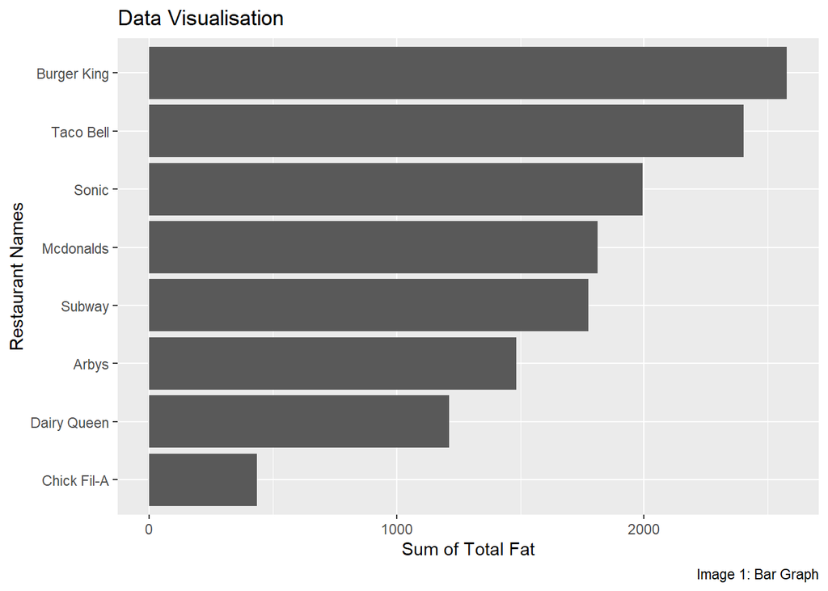

```r
library(ggplot2)
fastfood %>%
  group_by(restaurant) %>%
  summarise(sum_total_fat = sum(total_fat)) %>%
  ungroup() %>%
  mutate(restaurant = fct_reorder(restaurant, sum_total_fat)) %>%
  ggplot(aes(restaurant, sum_total_fat)) +
  geom_col ()+
  coord_flip()+

labs(x="Restaurant Names", y="Sum of Total Fat", title="Data Visualisation", caption="Image 1: Bar Graph")
```

#### Q-16 Add a variable to the dataset, which calculates the maximum total fat per type of restaurant and call it `max_total_fat`

```r
max_total_fat <- fastfood %>% group_by(restaurant) %>% mutate(max_total_fat = max(total_fat)) %>% ungroup ()

head(max_total_fat)
```

```
## # A tibble: 6 x 20
##    ...1 restaurant item             calories cal_fat total_fat sat_fat trans_fat
##   <dbl> <chr>      <chr>               <dbl>   <dbl>     <dbl>   <dbl>     <dbl>
## 1     1 Mcdonalds  Artisan Grilled~      380      60         7       2       0
## 2     2 Mcdonalds  Single Bacon Sm~      840     410        45      17       1.5
## 3     3 Mcdonalds  Double Bacon Sm~     1130     600        67      27       3
## 4     4 Mcdonalds  Grilled Bacon S~      750     280        31      10       0.5
## 5     5 Mcdonalds  Crispy Bacon Sm~      920     410        45      12       0.5
## 6     6 Mcdonalds  Big Mac               540     250        28      10       1
## # ... with 12 more variables: cholesterol <dbl>, sodium <dbl>,
## #   total_carb <dbl>, fiber <dbl>, sugar <dbl>, protein <dbl>, vit_a <dbl>,
## #   vit_c <dbl>, calcium <dbl>, salad <chr>, average_calories <dbl>,
## #   max_total_fat <dbl>
```

#### Q-17 Use observations for Mcdonalds to plot sugar variable against protein with `geom_point()`

[figure not shown]

```r
library(ggplot2)

fastfood%>% filter(restaurant == "Mcdonalds") %>% ggplot(aes(x = sugar, y = protein, color = restaurant, size=sugar)) +
  geom_point()+
  labs(x="Protein", y="Sugar", title="Data Visualisation", caption="Image 2: Point graph")
```

#### Q-18 Identify variable(s) which should be factors and transform their type into a factor variable.

```r
class(fastfood$restaurant)
```

```
## [1] "character"
```

```r
class(fastfood$salad)
```

```
## [1] "character"
```

```r
class(fastfood$item)
```

```
## [1] "character"
```

```r
class18 <- as_factor(fastfood$restaurant)
class19 <- as_factor(fastfood$salad)
class20 <- as_factor(fastfood$item)
```

#### Q-19 Read about `cut_number()` function using Help and add a new variable to the dataset `calories_type`. Use `calories` variable for `cut_number()` function to split it into 3 categories `n=3`, add labels `labels=c("low", "med", "high")` and make the dataset ordered.

```r
calories_type <- cut_number(fastfood$calories, n = 3, labels=c("low", "med", "high"))
 levels(calories_type)
```

```
## [1] "low"  "med"  "high"
```

```r
fastfood1 <- fastfood %>% mutate(calories_type)
```

#### Q-20 Create a dataviz that shows the distribution of `calories_type` in food items for each type of restaurant.

```r
fastfood1 %>% count (restaurant, calories_type, sort = TRUE)
```

```
## # A tibble: 24 x 3
##    restaurant  calories_type     n
##    <chr>       <fct>         <int>
##  1 Taco Bell   med              47
##  2 Taco Bell   low              46
##  3 Subway      low              41
##  4 Subway      high             33
##  5 Burger King high             30
##  6 Mcdonalds   high             24
##  7 Arbys       high             23
##  8 Sonic       high             23
##  9 Subway      med              22
## 10 Taco Bell   high             22
## # ... with 14 more rows
```

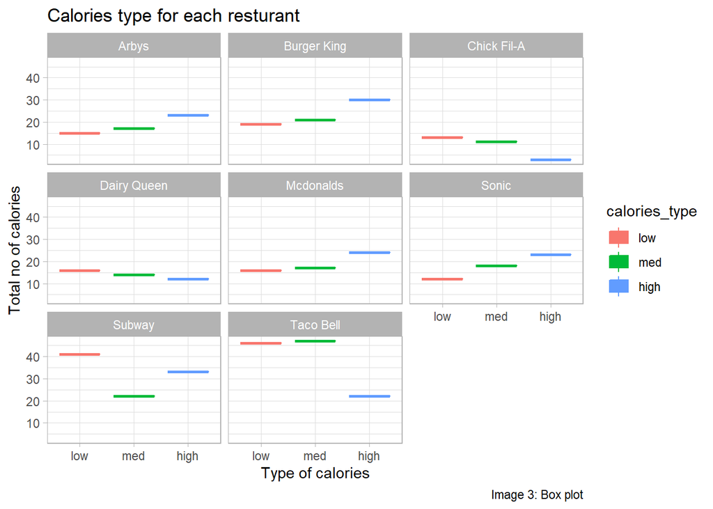

```r
fastfood1 %>% count (restaurant, calories_type, sort = TRUE) %>%
  ggplot(aes(calories_type, n, color=calories_type, fill = calories_type)) +
  geom_boxplot()+
  facet_wrap(~restaurant)+
  theme_light()+
   labs(x="Type of calories", y="Total no of calories", title="Calories type for each resturant", caption="Image 3: Box plot")
```

#### Q-21 The second variable should show the percentage of `trans_fat` in `total_fat`

```r
fastfood2 <-fastfood1 %>% mutate(trans_fat_percent = trans_fat/total_fat)
```

#### Q-22 Create a dataviz that shows the distribution of `trans_fat` in food items for each type of restaurant

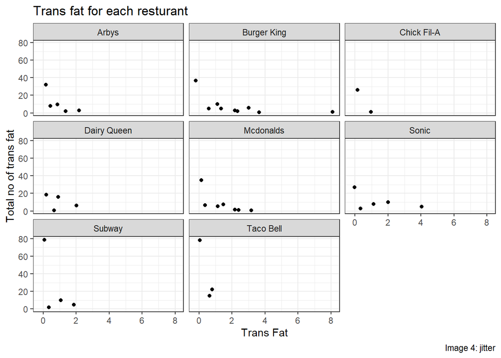

```r
fastfood2%>%
  count (restaurant, trans_fat, sort = TRUE) %>%
  ggplot(aes(trans_fat, n)) +
  geom_jitter()+
  facet_wrap(~restaurant)+
  theme_bw()+
labs(x="Trans Fat", y="Total no of trans fat", title="Trans fat for each resturant", caption="Image 4: jitter")
```

#### Q-23 Calculate and show the average (mean) `total_fat` for each type of restaurant.

```r
totalfat <-fastfood2 %>%
  group_by(restaurant) %>%
  summarise(total_fat = mean(total_fat))
```

[output not shown]

#### Q-24 create a dataviz that allow to compare different restaurants on this variable (`total_fat`).

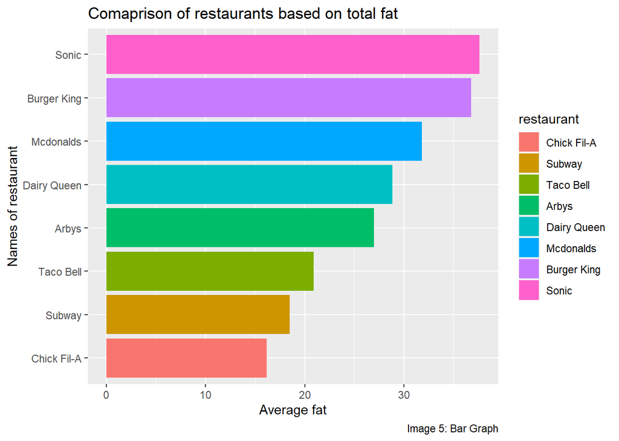

```r
fastfood2 %>%
  group_by(restaurant) %>%
summarise(totalfat = mean(total_fat)) %>%
ungroup() %>%
mutate(restaurant = fct_reorder(restaurant, totalfat)) %>%
ggplot(aes(restaurant, totalfat, fill=restaurant)) +
geom_col()+
coord_flip()+
theme_grey()+

labs(x="Names of restaurant", y="Average fat", title="Comaprison of restaurants based on total fat", caption="Image 5: Bar Graph")
```